# Dictionary Methods

### Apply topical dictionary

Next we will apply a topic-specific dictionary.

The logic is the same as the logic for sentiment dictionaries, however the lexicons we will now be measuring more than one category and considering topics as opposed to sentiment.

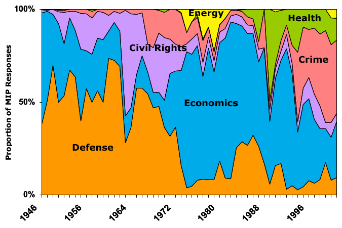

Source: Policy Agendas Project

In this exampple, we’ll load a corpus of speeches by representatives of the EU Member states, European Parliament, EU Commission, and the European Central Bank.

All speeches are stored (in some cases, translated) in English. The metadata contains information on the speakers, length, and occasion of the speeches.

[output not shown]

We’ll then apply an dictionary that identifies populist versus liberal terms. The word list for “populism” below is from Rooduijn and Pauwels (2011) and the word list for “liberalism” is created by Puschmann and Haim (2019).

```r
# Create dictionary
populism_liberalism_dict = dictionary(list(populism = c("elit*", "consensus*", "undemocratic*",
                                                            "referend*", "corrupt*", "propagand",
                                                            "politici*", "*deceit*", "*deceiv*",
                                                            "*betray*", "shame*", "scandal*",
                                                            "truth*", "dishonest*", "establishm*",
                                                            "ruling*"),
                                               liberalism = c("liber*", "free*", "indiv*", "open*",
                                                              "law*", "rules", "order", "rights",
                                                              "trade", "global", "inter*", "trans*",
                                                              "minori*", "exchange", "market*")))
populism_liberalism_dict
```

[output not shown]

We can apply the dictionary to the speech corpus, grouping by country or supranational entity (EU Commission, the EU Parliament, and the European Central Bank).

Note that we do not need to use `tokens_compund` because the dictionary does not include compound terms.

```r
# Transform to tokens
eu_toks = tokens(korpus.euspeech, remove_punct=TRUE) %>%
                tokens_remove(pattern = stopwords("en")) %>%
                tokens_group(groups = country) # grouping by country/entity
eu_dfm = dfm(eu_toks)

# Apply dictionary
eu_dfm_dict = dfm_lookup(eu_dfm, dictionary = populism_liberalism_dict)
eu_dfm_dict
```

[output not shown]

`dfm_weight` allows us to transform the dictionary dfm into a metric other than a count. Below, we’ll rely on same sentiment score metric we applied above. Here, we calculate the proportion of populist versus liberal words among total dictionary words.

```r
# Create proportion metric
dfm_eu_prop = dfm_weight(eu_dfm_dict, scheme = "prop")
convert(dfm_eu_prop, "data.frame")
```

[output not shown]

We may also want to examine the trend of populism over time. The process is the same, except for a change in the grouping variable.

```r
# Transform to tokens
eu_toks_year = tokens(korpus.euspeech, remove_punct=TRUE) %>%
                tokens_remove(pattern = stopwords("en")) %>%
                tokens_group(groups = Jahr) # grouping by country/entity
eu_dfm_year = dfm(eu_toks_year)

# Apply dictionary
eu_dfm_year_dict = dfm_lookup(eu_dfm_year, dictionary = populism_liberalism_dict)
eu_dfm_year_dict

# Create proportion
dfm_eu_prop_year = dfm_weight(eu_dfm_year_dict, scheme = "prop")
convert(dfm_eu_prop_year, "data.frame")
```

[output not shown]

Please bear in mind that while grouping can be useful for initial description, we often want to observe variation at the smallest unit available (in this case the speech).

Below, we generate the dfm, apply the dictionary, and transform the dictionary without grouping.

```r
# Create dfm
eu_dfm_nogroup = tokens(korpus.euspeech, remove_punct=TRUE) %>%
                tokens_remove(pattern = stopwords("en"))  %>% # removing grouping
                dfm(tolower = TRUE)  %>%
                dfm_remove(pattern = stopwords("english"))

# Apply dictionary
eu_dfm_dict = dfm_lookup(eu_dfm_nogroup, dictionary = populism_liberalism_dict)
eu_dfm_dict

# Transform to proportion
dfm_eu_prop = dfm_weight(eu_dfm_dict, scheme = "prop")
```

Now we can plot the variation of populist rhetoric by country based on values of individual speeches.

```r
# Generate df for plotting
eu_poplib_analysis =  convert(dfm_eu_prop, "data.frame") %>%
  bind_cols(korpus.euspeech.stats) %>%
  filter(length >= 1200) # removing short speeches

# Plot populism by country
ggplot(eu_poplib_analysis, aes(country, populism)) +
    geom_boxplot(outlier.size = 0) +
    geom_jitter(aes(country, populism),
                position = position_jitter(width = 0.4, height = 0),
                alpha = 0.1, size = 0.2, show.legend = F) +
    theme_classic() +
    theme(axis.text.x = element_text(angle = 45, vjust = 1, hjust = 1)) +
    xlab("Country") + ylab("Proportion populism") +
    ggtitle("Proportion of populist rhetoric among speeches of EU policymakers")

# Get average populism (for comparing visual to key values)
aggregate(populism ~ country, data = eu_poplib_analysis, mean)
aggregate(populism ~ country, data = eu_poplib_analysis, median)
```

[output not shown]

[output not shown]

### Homework

#### Discussion Question:

Think back to the last module yesterday (word frequencies). What is the advantage of sentiment analysis over word frequency approaches to answer questions about emotion and valence, for example whether Trump’s tweets were written by different people?**

#### Coding Question:

1. Load the immigration tweet corpus (we same data we used in our last exercise, now saved as a corpus).
2. Tokenize the corpus (retain all years, 2013-2017).
3. Apply the NRC dictionary in Quanteda (use ‘data_dictionary_NRC’) to measure sentiment.
4. Find the average sentiment score for each year in the sample.